# Анализ вакансий сайта hh.ru

**Задача**

Выявить различия в предлагаемых вакансиях для Аналитиков данных (Data Analyst, DA) и специалистов Data Science (DS)

**Описание данных**

Два датасета получены из API HH.ru имеют одинаковую следующую структуру:

- id - идентификатор вакансии;
- name - название вакансии;
- published_at - дата публикации;
- alternate_url - ссылка на страницу с вакансией;
- type - статус вакансии?;
- employer - работодатель;
- department - отдел, в котором открыта вакансия;
- area - регион вакансии;
- experience - требуемый опыт работы;
- key_skills - ключевые навыки;
- schedule - режим работы;
- employment - тип занятости;
- description - описание вакансии;
- description_lemmatized - леммы (начальные форма слов), исходя из описания вакансии (≈ ключевые слова);
- salary_from - минимальная граница ЗП;
- salary_to - максимальная граница ЗП;
- salary_bin - вилка ЗП;
- key_skills_from_key_skills_field - перечень ключевых навыков;
- hard_skills_from_description - требуемые хард скиллы, исходя из описания вакансии;
- soft_skills_from_description - требуемые софт скиллы, исходя из описания вакансии;

Данные соответствую форматам

Просмотрим информацию о датафрейме

|  | идентификатор | дата публикации | минимальная граница ЗП | максимальная граница ЗП |
| --- | --- | --- | --- | --- |
| count | 9.720000e+02 | 972 | 81.000000 | 81.000000 |
| mean | 9.514522e+07 | 2024-04-08 00:29:28.143004160 | 165505.555556 | 260831.481481 |
| min | 6.741115e+07 | 2024-02-29 15:01:35 | 25000.000000 | 30000.000000 |
| 25% | 9.438909e+07 | 2024-03-27 09:37:45.750000128 | 110000.000000 | 200000.000000 |
| 50% | 9.549617e+07 | 2024-04-10 16:22:10 | 150000.000000 | 250000.000000 |
| 75% | 9.683393e+07 | 2024-04-22 15:28:47.750000128 | 200000.000000 | 350000.000000 |
| max | 9.814129e+07 | 2024-04-30 12:51:55 | 350000.000000 | 550000.000000 |
| std | 2.528154e+06 | NaN | 72818.799084 | 114328.005221 |

Сравним пропуски на диаграмме

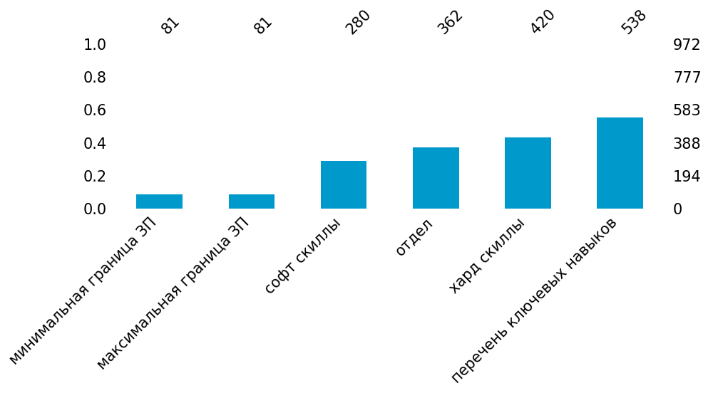

Поищем зависимость между пропусками

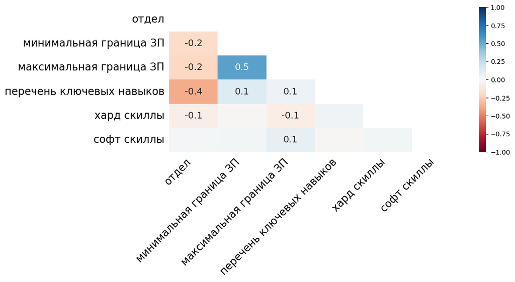

### Доли вакансий аналитиков и сайнтистов

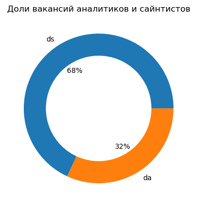

- Вакансий `DS в 2 раза` больше чем вакансий DA

### Доли грейдов среди вакансий Аналитик данных и Специалист по Data Science.

```
type_a                  da   ds  all  da_prc  ds_prc
experience
Senior (6+ years)        3   23   26   0.31%   2.37%
Junior (no experince)    9   26   35   0.93%   2.67%
Middle (3-6 years)     120  324  444  12.35%  33.33%
Junior+ (1-3 years)    178  289  467  18.31%  29.73%
All                    310  662  972  31.89%  68.11%
```

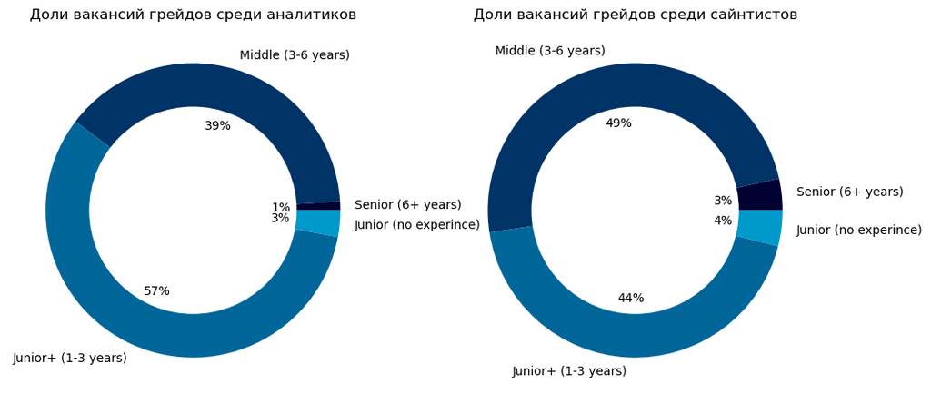

- В вакансиях DA наиболее популярен грейд Junior+ (1-3 years) - `57%`

- В вакансиях DS наиболее популярен грейд Middle (3-6 years) - `49%`

- Данных о грейдах Junior (no experince) и Senior (6+ years) очень мало

#### Популярные навыки DA

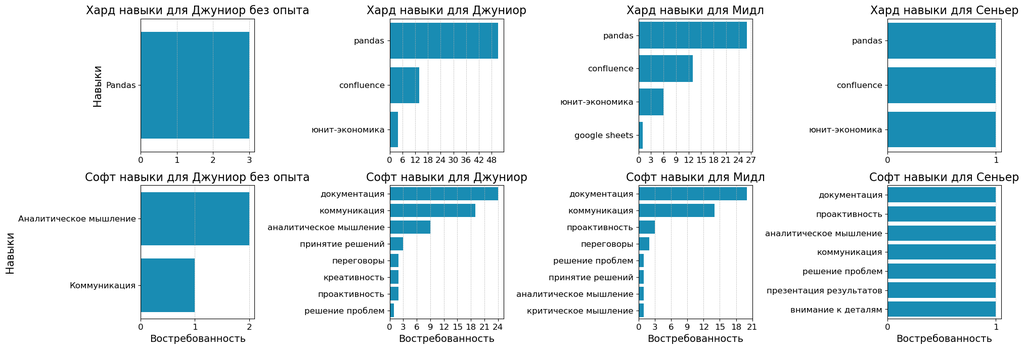

Выводы

- Junior (no experince) требуется знание Pandas, Аналитическое мышление и Коммуникация

- Junior+ (1-3 years) требуется знание Pandas, confluence, Документация и Коммуникация

- Middle (3-6 years) требуется знание Pandas, confluence, Документация и Коммуникация

- Сеньорам требуется большой спектр навыков которые имеют равное значение

#### Популярные навыки DS

[figure not shown]